# **IoT-Based Smart Farming System for Crop Yield Prediction**

## **Exploratory Data Analysis and Summary Statistics**

## **1. Imports & Configuration**

Below code sets up a data analysis environment using popular libraries: **pandas** for data manipulation, **numpy** for numerical operations, and **matplotlib.pyplot** and **seaborn** for data visualization. It imports the `datetime` module for handling dates and times. The `pd.set_option` lines configure pandas to display all columns and format floating-point numbers with two decimal places for better readability. The `plt.rcParams` and `sns.set_style` lines customize the appearance of plots, setting a default figure size of 10x5 inches and applying a clean "whitegrid" style from seaborn for improved visual clarity.

```python
# Import essential libraries for data analysis and visualization
import pandas as pd  # For data manipulation and analysis
import numpy as np  # For numerical operations
import matplotlib.pyplot as plt  # For basic plotting
import seaborn as sns  # For advanced statistical visualizations
from datetime import datetime  # For handling date and time

# Configure pandas to display all columns and format floating-point numbers
pd.set_option("display.max_columns", None)  # Show all columns
pd.set_option("display.float_format", lambda x: f"{x:,.2f}")  # Format floats to 2 decimal places

# Configure plot aesthetics
plt.rcParams["figure.figsize"] = (10, 5)  # Set default figure size
sns.set_style("whitegrid")  # Use a clean grid style for plots
```

## **2. Load Dataset**

This code reads a CSV file named **"Smart_Farming_Crop_Yield_2024.csv"** into a pandas DataFrame called `df`, which allows us to work with the data in a structured tabular format. The `pd.read_csv()` function loads the file, automatically parsing its contents into columns and rows. The `df.head()` method then displays the first five rows of the DataFrame, providing a quick preview of the data's structure, column names, and initial values—helping you verify that the file was loaded correctly and understand its contents at a glance.

```python
# Load the dataset from a CSV file into a pandas DataFrame
df = pd.read_csv("Smart_Farming_Crop_Yield_2024.csv")

# Display the first 5 rows to verify the data structure
df.head()
```

|  | farm_id | region | crop_type | soil_moisture_% | soil_pH | temperature_C | rainfall_mm | humidity_% | sunlight_hours | irrigation_type | fertilizer_type | pesticide_usage_ml | sowing_date | harvest_date | total_days | yield_kg_per_hectare | sensor_id | timestamp | latitude | longitude | NDVI_index | crop_disease_status |
| --- | --- | --- | --- | --- | --- | --- | --- | --- | --- | --- | --- | --- | --- | --- | --- | --- | --- | --- | --- | --- | --- | --- |
| 0 | FARM0001 | North India | Wheat | 35.95 | 5.99 | 17.79 | 75.62 | 77.03 | 7.27 | NaN | Organic | 6.34 | 2024-01-08 | 2024-05-09 | 122 | 4,408.07 | SENS0001 | 2024-03-19 | 14.97 | 83.00 | 0.63 | Mild |
| 1 | FARM0002 | South USA | Soybean | 19.74 | 7.24 | 30.18 | 89.91 | 61.13 | 5.67 | Sprinkler | Inorganic | 9.60 | 2024-02-04 | 2024-05-26 | 112 | 5,389.98 | SENS0002 | 2024-04-21 | 16.61 | 70.87 | 0.58 | NaN |
| 2 | FARM0003 | South USA | Wheat | 29.32 | 7.16 | 27.37 | 265.43 | 68.87 | 8.23 | Drip | Mixed | 15.26 | 2024-02-03 | 2024-06-26 | 144 | 2,931.16 | SENS0003 | 2024-02-28 | 19.50 | 79.07 | 0.80 | Mild |
| 3 | FARM0004 | Central USA | Maize | 17.33 | 6.03 | 33.73 | 212.01 | 70.46 | 5.03 | Sprinkler | Organic | 25.80 | 2024-02-21 | 2024-07-04 | 134 | 4,227.80 | SENS0004 | 2024-05-14 | 31.07 | 85.52 | 0.44 | NaN |
| 4 | FARM0005 | Central USA | Cotton | 19.37 | 5.92 | 33.86 | 269.09 | 55.73 | 7.93 | NaN | Mixed | 25.65 | 2024-02-05 | 2024-05-20 | 105 | 4,979.96 | SENS0005 | 2024-04-13 | 16.57 | 81.69 | 0.84 | Severe |

This output displays the first five rows of a dataset focused on **smart farming and crop yield for 2024**, revealing a detailed snapshot of agricultural data from different farms. Each row represents a unique farm (`farm_id`) and includes attributes like **region, crop type, soil conditions (moisture, pH), environmental factors (temperature, rainfall, humidity, sunlight), farming practices (irrigation, fertilizer, pesticide usage), sowing and harvest dates, total growth days, yield per hectare, sensor data (ID, timestamp, GPS coordinates), and crop health indicators (NDVI index and disease status)**. Notably, the dataset captures diverse farming conditions—such as missing values for irrigation type in some entries—and highlights variations in crop yield, disease severity, and environmental parameters across regions and crop types, providing a foundation for analyzing factors influencing agricultural productivity.

Below line of code uses Python's **f-string formatting** to print the **shape** of the pandas DataFrame `df`, which is a tuple representing the number of rows and columns in the dataset. The `df.shape` attribute returns these dimensions, and the `print()` function outputs the result in a user-friendly format, such as `"Shape: (1000, 20)"`, indicating that the DataFrame contains 1,000 rows and 20 columns. This is a quick way to understand the size and structure of the dataset at a glance.

```python
# Print the shape of the DataFrame (number of rows, number of columns)
print(f"Shape: {df.shape}")
```

```
Shape: (500, 22)
```

The output **"Shape: (500, 22)"** indicates that the DataFrame contains **500 rows and 22 columns**, meaning the dataset includes 500 individual records (such as farm entries or observations) and 22 distinct attributes (like farm ID, crop type, soil moisture, yield, etc.) for each record. This concise summary helps us quickly grasp the dataset's size and complexity, confirming that we are working with a moderately large dataset suitable for in-depth analysis or modeling.

## **3. Data Structure & Types**

The code `df.info()` is a pandas method that provides a **concise summary** of the DataFrame `df`, including the **number of rows and columns, column names, data types** (e.g., int64, float64, object, datetime64), and the **count of non-null values** for each column. This output helps us quickly assess the dataset's structure, identify missing values, verify data types, and estimate memory usage, making it essential for initial data exploration and cleaning.

```python
# Display a summary of the DataFrame, including data types and non-null counts
df.info()
```

```
<class 'pandas.core.frame.DataFrame'>
RangeIndex: 500 entries, 0 to 499
Data columns (total 22 columns):
 #   Column                Non-Null Count  Dtype
---  ------                --------------  -----
 0   farm_id               500 non-null    object
 1   region                500 non-null    object
 2   crop_type             500 non-null    object
 3   soil_moisture_%       500 non-null    float64
 4   soil_pH               500 non-null    float64
 5   temperature_C         500 non-null    float64
 6   rainfall_mm           500 non-null    float64
 7   humidity_%            500 non-null    float64
 8   sunlight_hours        500 non-null    float64
 9   irrigation_type       350 non-null    object
 10  fertilizer_type       500 non-null    object
 11  pesticide_usage_ml    500 non-null    float64
 12  sowing_date           500 non-null    object
 13  harvest_date          500 non-null    object
 14  total_days            500 non-null    int64
 15  yield_kg_per_hectare  500 non-null    float64
 16  sensor_id             500 non-null    object
 17  timestamp             500 non-null    object
 18  latitude              500 non-null    float64
 19  longitude             500 non-null    float64
 20  NDVI_index            500 non-null    float64
 21  crop_disease_status   370 non-null    object
dtypes: float64(11), int64(1), object(10)
memory usage: 86.1+ KB
```

The code `df.dtypes` returns a **pandas Series** showing the data type of each column in the DataFrame `df`, such as `object` (typically strings or mixed types), `float64` (floating-point numbers), or `int64` (integers). This helps us quickly identify the type of data stored in each column, which is crucial for ensuring compatibility with analysis or visualization functions and for planning any necessary type conversions (e.g., converting strings to dates or numbers).

```python
# Display the data types of each column
df.dtypes
```

|  | 0 |
| --- | --- |
| farm_id | object |
| region | object |
| crop_type | object |
| soil_moisture_% | float64 |
| soil_pH | float64 |
| temperature_C | float64 |
| rainfall_mm | float64 |
| humidity_% | float64 |
| sunlight_hours | float64 |
| irrigation_type | object |
| fertilizer_type | object |
| pesticide_usage_ml | float64 |
| sowing_date | object |
| harvest_date | object |
| total_days | int64 |
| yield_kg_per_hectare | float64 |
| sensor_id | object |
| timestamp | object |
| latitude | float64 |
| longitude | float64 |
| NDVI_index | float64 |
| crop_disease_status | object |

**dtype:** object

The output of `df.dtypes` reveals the **data types** for each column in the DataFrame: **11 columns are `float64`** (numeric values with decimals, like soil moisture, temperature, and yield), **1 column is `int64`** (whole numbers, like `total_days`), and **10 columns are `object`** (typically strings or mixed types, such as IDs, dates, and categorical variables like `crop_type` and `irrigation_type`). This breakdown is essential for identifying columns that may need type conversion—such as converting `sowing_date` and `harvest_date` from `object` to `datetime`—to enable time-based analysis or ensure compatibility with specific functions.

## **4. Missing Value Analysis**

The code calculates the **percentage of missing values** for each column in the DataFrame `df`. It first uses `df.isna()` to create a boolean DataFrame indicating missing values, then `.mean()` to compute the average (proportion) of missing values per column, and `.mul(100)` to convert these proportions to percentages. The results are sorted in descending order with `.sort_values(ascending=False)` and reset to a clean DataFrame with `.reset_index()`. Finally, the columns are renamed to **"column"** and **"missing_percentage"** for clarity, providing a concise summary of missing data across the dataset.

```python
# Calculate the percentage of missing values for each column
missing_df = (
    df.isna()  # Identify missing values
    .mean()  # Calculate the mean (proportion) of missing values
    .mul(100)  # Convert to percentage
    .sort_values(ascending=False)  # Sort in descending order
    .reset_index()  # Reset index for clarity
)
missing_df.columns = ["column", "missing_percentage"]  # Rename columns
missing_df  # Display the result
```

|  | column | missing_percentage |
| --- | --- | --- |
| 0 | irrigation_type | 30.00 |
| 1 | crop_disease_status | 26.00 |
| 2 | crop_type | 0.00 |
| 3 | soil_moisture_% | 0.00 |
| 4 | farm_id | 0.00 |
| 5 | region | 0.00 |
| 6 | temperature_C | 0.00 |
| 7 | soil_pH | 0.00 |
| 8 | humidity_% | 0.00 |
| 9 | rainfall_mm | 0.00 |
| 10 | fertilizer_type | 0.00 |
| 11 | pesticide_usage_ml | 0.00 |
| 12 | sowing_date | 0.00 |
| 13 | sunlight_hours | 0.00 |
| 14 | harvest_date | 0.00 |
| 15 | total_days | 0.00 |
| 16 | sensor_id | 0.00 |
| 17 | yield_kg_per_hectare | 0.00 |
| 18 | timestamp | 0.00 |
| 19 | latitude | 0.00 |
| 20 | longitude | 0.00 |
| 21 | NDVI_index | 0.00 |

The output shows the **percentage of missing values** for each column in the dataset:

- **`irrigation_type`** has **30%** missing values, meaning almost a third of the entries lack this information.
- **`crop_disease_status`** has **26%** missing values, indicating a significant portion of records do not include disease status.
- **All other columns** (e.g., `crop_type`, `soil_moisture_%`, `farm_id`, etc.) have **0%** missing values, meaning they are fully populated.

This summary highlights which columns require attention for **data imputation or cleaning** before further analysis, especially if `irrigation_type` or `crop_disease_status` are critical for the study.

Below code creates a **horizontal bar plot** to visualize the percentage of missing values for each feature (column) in the dataset. It uses `sns.barplot()` from the seaborn library to plot the `missing_percentage` on the x-axis and the `column` names on the y-axis, with the data sourced from the `missing_df` DataFrame. The plot is customized with a title ("Missing Value Percentage by Feature") and labeled axes ("Missing %" and "Feature") for clarity, and `plt.show()` renders the plot, making it easy to identify which columns have the most missing data at a glance.

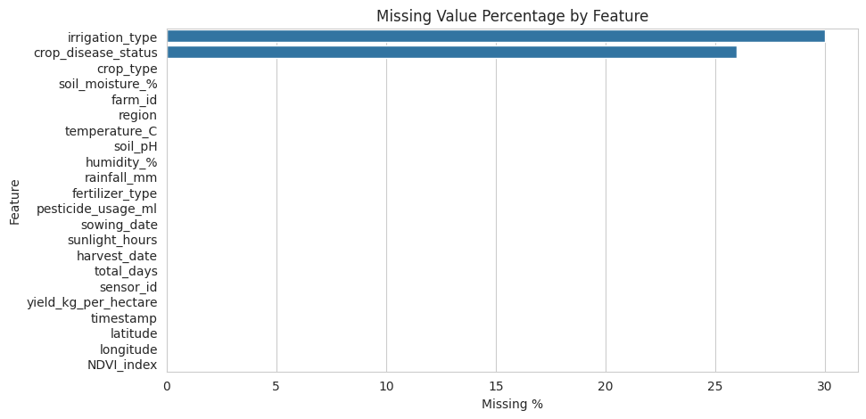

```python
# Visualize missing value percentages using a bar plot
plt.figure()
sns.barplot(
    data=missing_df,
    x="missing_percentage",
    y="column"
)
plt.title("Missing Value Percentage by Feature")
plt.xlabel("Missing %")
plt.ylabel("Feature")
plt.show()
```

The bar plot visually summarizes the **percentage of missing values** for each feature in your dataset. It clearly shows that only two features—**`irrigation_type` (30%)** and **`crop_disease_status` (26%)**—have missing data, with all other features being fully populated (0% missing). This highlights that these two columns require attention for data imputation or handling, while the rest of the dataset is complete and ready for analysis. The plot effectively communicates the extent of missingness at a glance, helping prioritize data cleaning efforts.

## **5. Basic Statistical Summary**

### **Numerical Features**

The code `df.describe()` generates a **statistical summary** of the numeric columns in the pandas DataFrame `df`. It provides key metrics for each column, including the **count of non-null values, mean, standard deviation, minimum, 25th percentile (Q1), median (50th percentile), 75th percentile (Q3), and maximum**, offering a quick overview of the data distribution, central tendency, and spread. This is particularly useful for identifying outliers, understanding the range of values, and assessing the overall structure of the numeric data in the dataset.

```python
# Generate descriptive statistics for numerical columns
df.describe()
```

|  | soil_moisture_% | soil_pH | temperature_C | rainfall_mm | humidity_% | sunlight_hours | pesticide_usage_ml | total_days | yield_kg_per_hectare | latitude | longitude | NDVI_index |
| --- | --- | --- | --- | --- | --- | --- | --- | --- | --- | --- | --- | --- |
| count | 500.00 | 500.00 | 500.00 | 500.00 | 500.00 | 500.00 | 500.00 | 500.00 | 500.00 | 500.00 | 500.00 | 500.00 |
| mean | 26.75 | 6.52 | 24.68 | 181.69 | 65.19 | 7.03 | 26.59 | 119.50 | 4,032.93 | 22.44 | 80.39 | 0.60 |
| std | 10.15 | 0.59 | 5.35 | 72.29 | 14.64 | 1.69 | 13.20 | 16.80 | 1,174.43 | 7.28 | 5.91 | 0.18 |
| min | 10.16 | 5.51 | 15.00 | 50.17 | 40.23 | 4.01 | 5.05 | 90.00 | 2,023.56 | 10.00 | 70.02 | 0.30 |
| 25% | 17.89 | 6.03 | 20.30 | 119.22 | 51.86 | 5.67 | 14.95 | 105.75 | 2,994.82 | 16.26 | 75.37 | 0.45 |
| 50% | 25.86 | 6.53 | 24.66 | 191.55 | 65.69 | 7.00 | 25.98 | 119.00 | 4,071.69 | 21.98 | 80.65 | 0.61 |
| 75% | 36.02 | 7.04 | 29.09 | 239.03 | 77.99 | 8.47 | 38.01 | 134.00 | 5,062.11 | 28.53 | 85.65 | 0.75 |
| max | 44.98 | 7.50 | 34.84 | 298.96 | 90.00 | 10.00 | 49.94 | 150.00 | 5,998.29 | 34.98 | 89.99 | 0.90 |

The output of `df.describe()` provides a **statistical summary** of the numeric columns in your dataset. For each feature—such as `soil_moisture_%`, `soil_pH`, `temperature_C`, and others—it shows the **count (500, meaning no missing values for these columns), mean, standard deviation, minimum, 25th percentile (Q1), median (50%), 75th percentile (Q3), and maximum values**. For example, the average `yield_kg_per_hectare` is approximately **4,032.93 kg**, with a wide range from **2,023.56 kg to 5,998.29 kg**, indicating variability in crop productivity. The `temperature_C` ranges from **15°C to 34.84°C**, and `rainfall_mm` varies significantly (50.17 mm to 298.96 mm), suggesting diverse environmental conditions. This summary helps identify typical values, spread, and potential outliers in the dataset.

### **Categorical Features**

The code `df.describe(include="object")` generates a **summary statistics table** for all **categorical (non-numeric) columns** in the DataFrame `df`. Unlike the default `describe()`—which focuses on numeric columns—this version provides insights for `object` (typically string or categorical) data types, including the **count of non-null values, number of unique entries, most frequent value (top), and its frequency**. This is useful for understanding the distribution and diversity of categorical variables, such as farm IDs, regions, or crop types, in the dataset.

```python
# Generate descriptive statistics for categorical columns
df.describe(include="object")
```

|  | farm_id | region | crop_type | irrigation_type | fertilizer_type | sowing_date | harvest_date | sensor_id | timestamp | crop_disease_status |
| --- | --- | --- | --- | --- | --- | --- | --- | --- | --- | --- |
| count | 500 | 500 | 500 | 350 | 500 | 500 | 500 | 500 | 500 | 370 |
| unique | 500 | 5 | 5 | 3 | 3 | 84 | 123 | 500 | 172 | 3 |
| top | FARM0500 | Central USA | Maize | Sprinkler | Inorganic | 2024-03-05 | 2024-06-28 | SENS0500 | 2024-04-14 | Severe |
| freq | 1 | 109 | 111 | 121 | 167 | 15 | 10 | 1 | 10 | 133 |

The output of `df.describe(include="object")` provides a **summary of the categorical (object-type) columns** in the dataset. For each column—such as `farm_id`, `region`, `crop_type`, and `irrigation_type`—it shows the **count of non-null entries, number of unique values, most frequent value (top), and its frequency (freq)**. For example, there are **5 unique regions**, with **Central USA** being the most common (109 occurrences), and **5 crop types**, with **Maize** appearing most frequently (111 times). The `irrigation_type` column has only **3 unique values**, with **Sprinkler** being the most common (121 entries). Notably, `irrigation_type` and `crop_disease_status` have fewer non-null counts (350 and 370, respectively), confirming the presence of missing values. This summary helps you understand the distribution and prevalence of categorical variables in the dataset.

## **6. Target Variable Analysis (Yield)**

This code creates a **histogram with a kernel density estimate (KDE) line** to visualize the distribution of the `yield_kg_per_hectare` column in the DataFrame. Using `sns.histplot()` from the seaborn library, it divides the data into **30 bins** to show the frequency of yield values, while `kde=True` overlays a smooth curve representing the estimated probability density function. The plot is labeled with a title, **"Distribution of Crop Yield (kg/hectare)"**, and rendered with `plt.show()`, helping us quickly assess the shape, central tendency, and spread of crop yield data.

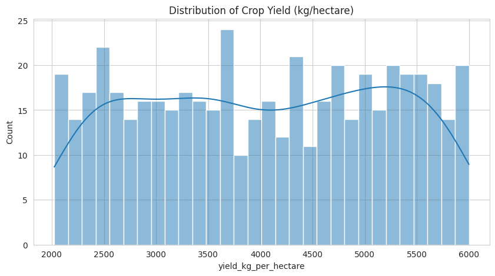

```python
# Plot the distribution of crop yield with a KDE line
sns.histplot(df["yield_kg_per_hectare"], bins=30, kde=True)
plt.title("Distribution of Crop Yield (kg/hectare)")
plt.show()
```

Below code generates a **boxplot** to visually assess the distribution and detect outliers in the `yield_kg_per_hectare` column of your DataFrame. Using `sns.boxplot()` from the seaborn library, it plots the **median, quartiles (25th and 75th percentiles), and potential outliers** (points outside the "whiskers," typically 1.5 times the interquartile range). The plot is labeled with the title **"Outlier Check – Crop Yield"** and displayed with `plt.show()`, making it easy to identify the central tendency, spread, and any anomalous yield values that may need further investigation.

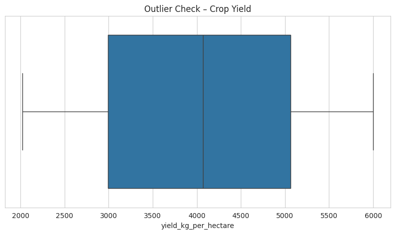

```python
# Check for outliers in crop yield using a boxplot
sns.boxplot(x=df["yield_kg_per_hectare"])
plt.title("Outlier Check – Crop Yield")
plt.show()
```

The boxplot for **crop yield (kg/hectare)** visually summarizes the distribution and highlights potential outliers in your dataset. The box represents the **interquartile range (IQR)**, with the bottom and top edges showing the **25th and 75th percentiles**, respectively, and the line inside the box indicating the **median yield** (around 4000 kg/hectare). The "whiskers" extend to the minimum and maximum values within 1.5 times the IQR, while the dots outside the whiskers (if any) would represent outliers—though none are visible here, suggesting a relatively consistent yield range. The plot confirms that most yields fall between **approximately 3000 and 5000 kg/hectare**, with a few values extending toward the lower and upper extremes, providing a clear view of the central tendency and spread of crop productivity.

## **7. Numerical Feature Distributions**

Below code automates the process of plotting **distribution histograms with KDE lines** for all numeric columns in the DataFrame `df`, except for `yield_kg_per_hectare`. It first selects the numeric columns using `df.select_dtypes(include="number").columns`, then iterates over each column with a `for` loop. For each column, it generates a histogram and KDE plot using `sns.histplot()`, sets a dynamic title with `plt.title()`, and displays the plot with `plt.show()`. This approach allows you to quickly visualize the distribution, central tendency, and spread of every numeric feature in the dataset, aiding in exploratory data analysis.

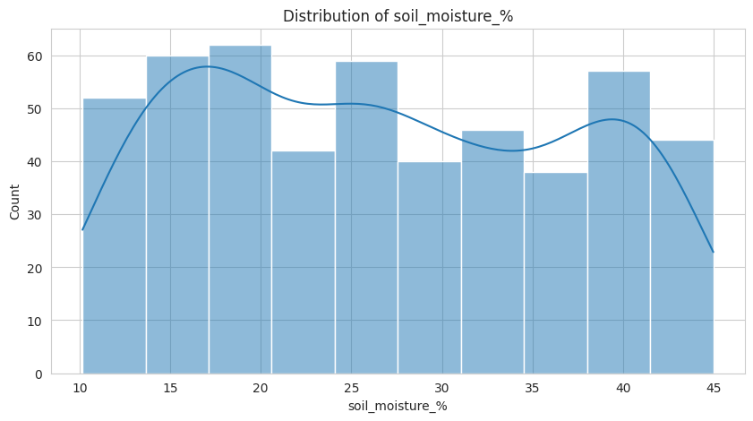

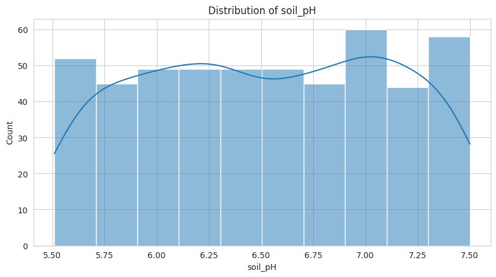

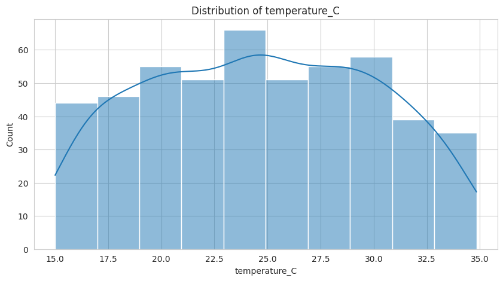

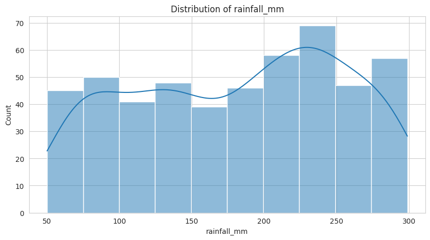

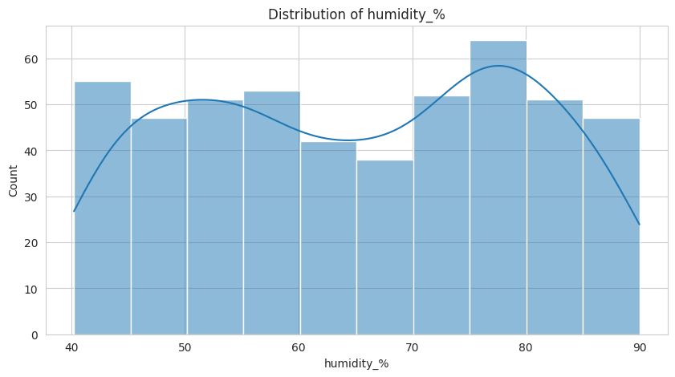

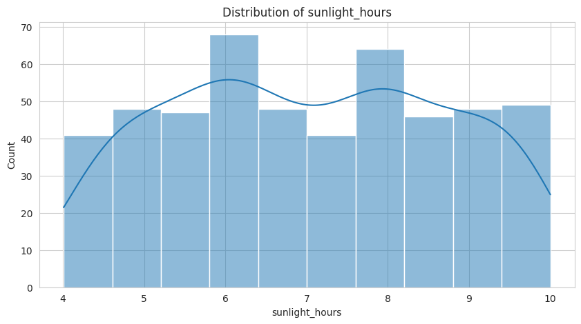

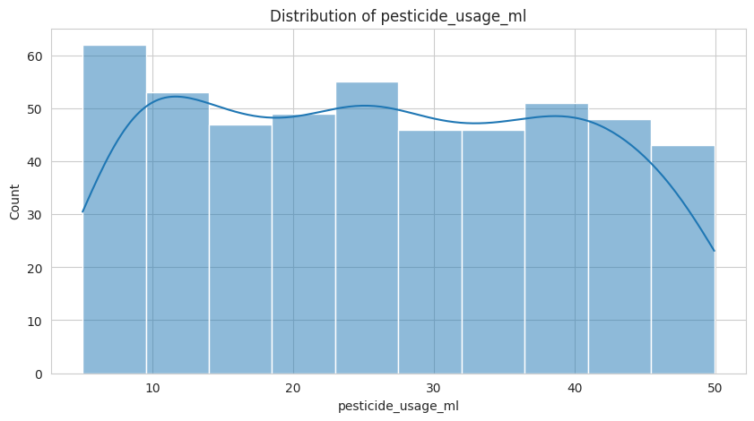

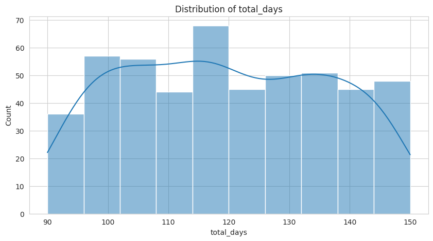

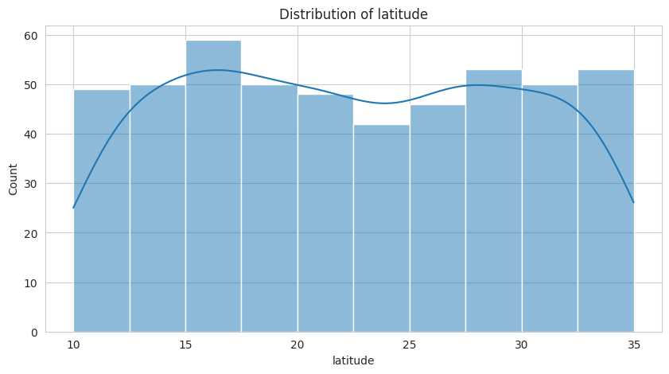

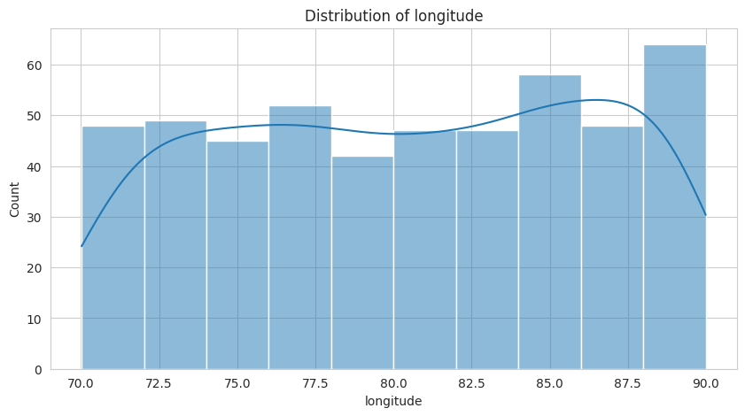

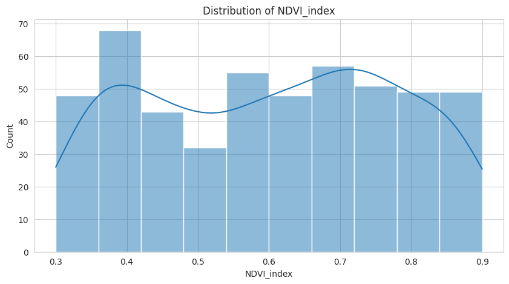

```python
# Plot distributions for all numerical columns except yield
num_cols = df.select_dtypes(include="number").columns
for col in num_cols:
    if col != "yield_kg_per_hectare":
        sns.histplot(df[col], kde=True)
        plt.title(f"Distribution of {col}")
        plt.show()
```

## **8. Categorical Feature Analysis**

Below code automates the creation of **bar plots** for all categorical (object-type) columns in the DataFrame `df`. It first selects the categorical columns using `df.select_dtypes(include="object").columns`, then iterates over each column with a `for` loop. For each column, it calculates the frequency of each unique value using `df[col].value_counts()`, plots these frequencies as a bar chart with `plot(kind="bar")`, and customizes the plot with a dynamic title (`f"Value Counts: {col}"`) and a y-axis label ("Count"). Each plot is displayed using `plt.show()`, allowing us to quickly visualize the distribution and prevalence of categories in the dataset, which is useful for understanding the composition and balance of categorical variables.

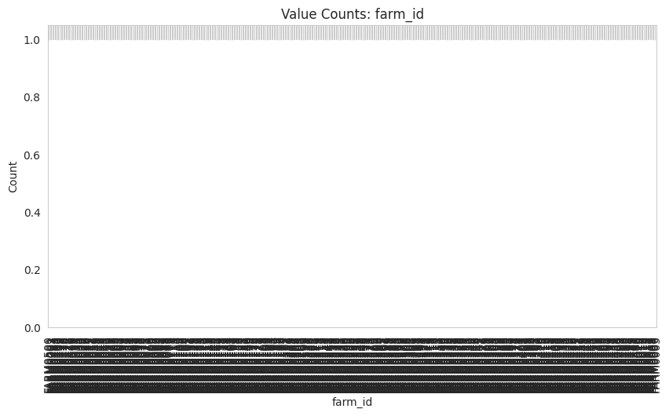

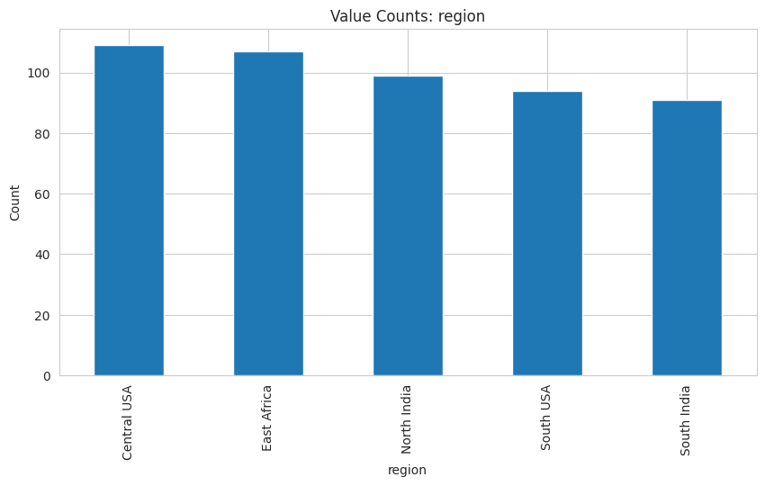

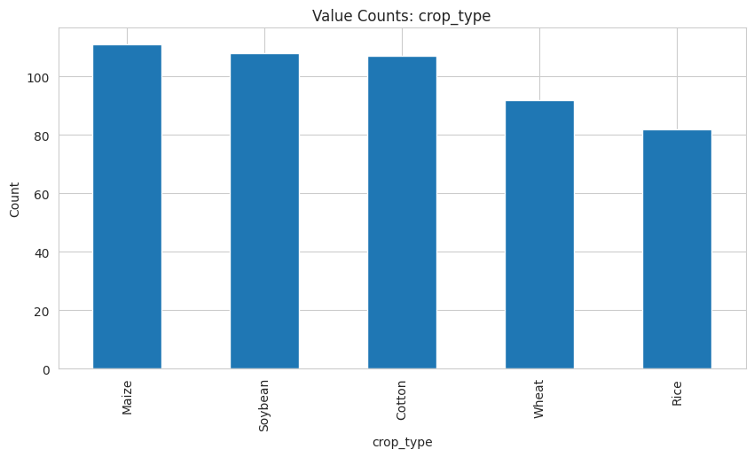

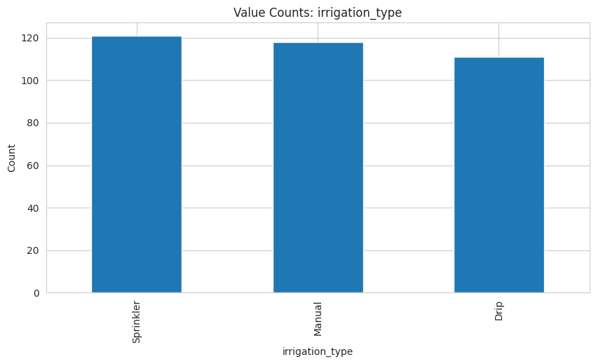

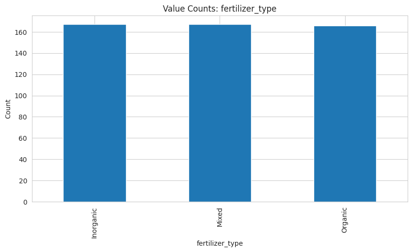

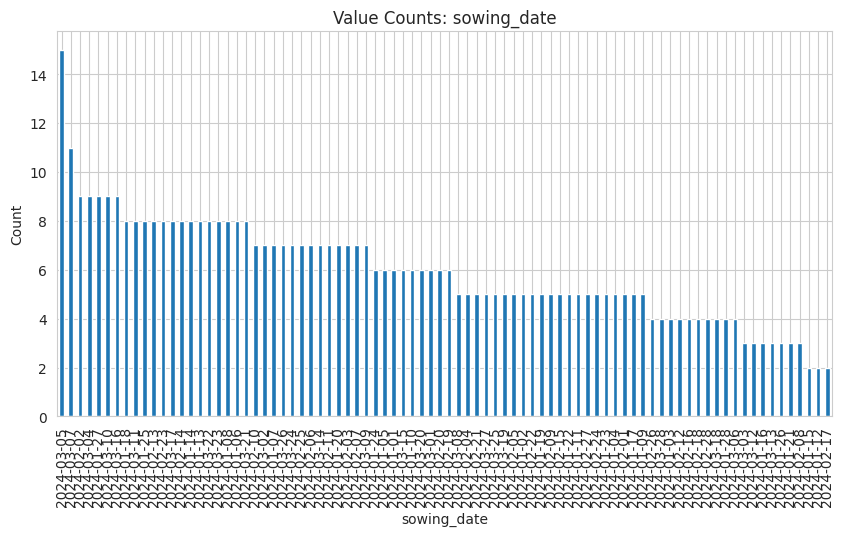

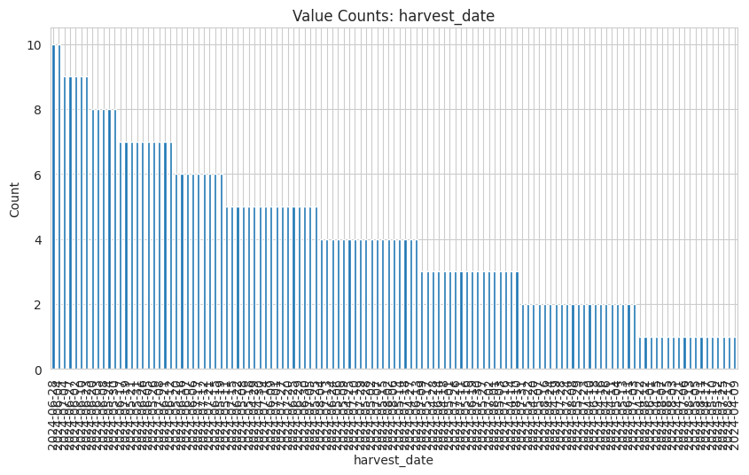

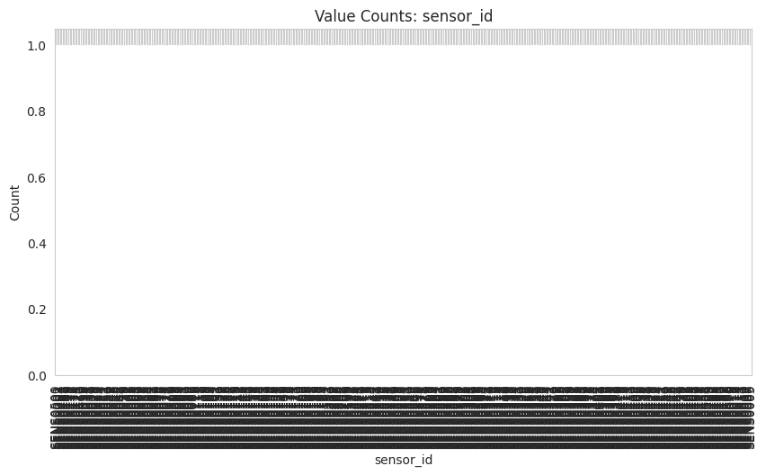

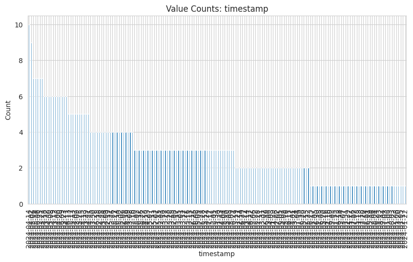

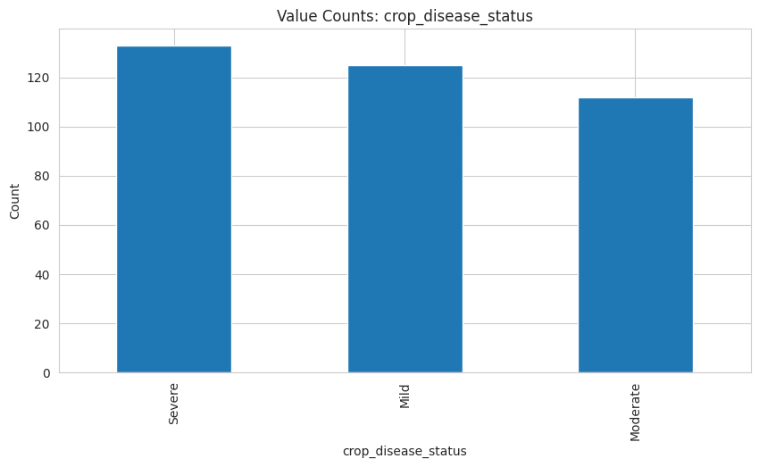

```python
# Plot value counts for all categorical columns
cat_cols = df.select_dtypes(include="object").columns
for col in cat_cols:
    plt.figure()
    df[col].value_counts().plot(kind="bar")
    plt.title(f"Value Counts: {col}")
    plt.ylabel("Count")
    plt.show()
```

For **`crop_type`**, **Maize**, **Soybean**, and **Cotton** are the most common crops, while **Wheat** and **Rice** are less frequent. The **`irrigation_type`** plot highlights **Sprinkler** as the most widely used method, followed by **Manual** and **Drip**. The **`fertilizer_type`** distribution is nearly equal across **Inorganic**, **Mixed**, and **Organic**, indicating no strong preference for any single type. The **`crop_disease_status`** plot shows that **Severe** disease cases are the most reported, followed by **Mild** and **Moderate**, which may indicate varying levels of crop health challenges across farms.

## **9. Yield *vs* Categorical Variables**

Below code generates **boxplots** to compare the distribution of **crop yield (kg/hectare)** across different categories of four categorical variables: `crop_type`, `region`, `irrigation_type`, and `fertilizer_type`. For each variable, it creates a new figure, uses `sns.boxplot()` to plot the yield values (`y="yield_kg_per_hectare"`) against the categories (`x=col`), and rotates the x-axis labels by 45 degrees for better readability. Each plot is given a descriptive title (`f"Yield vs {col}"`) and displayed with `plt.show()`. This approach helps visualize how yield varies across different crops, regions, irrigation methods, and fertilizer types, making it easier to identify patterns, differences in central tendency, and potential outliers.

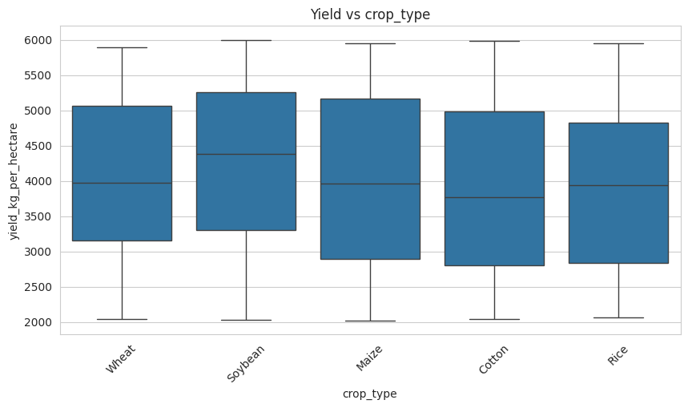

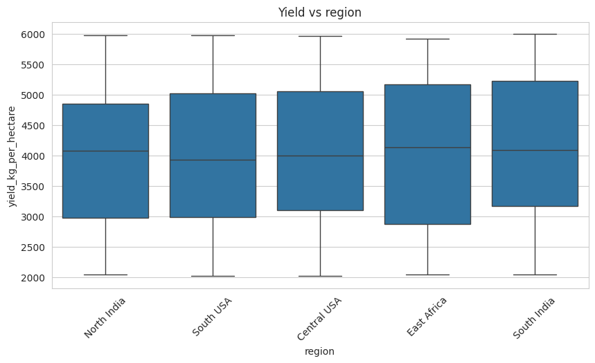

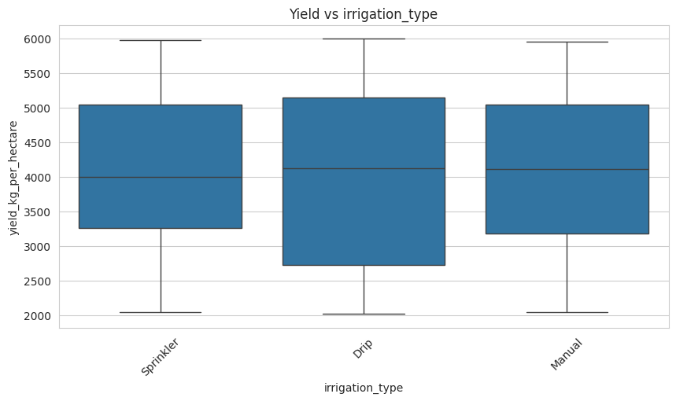

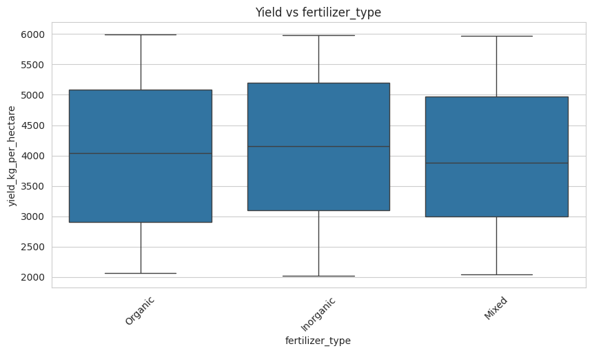

```python
# Plot boxplots to compare yield across categories
for col in ["crop_type", "region", "irrigation_type", "fertilizer_type"]:
    plt.figure()
    sns.boxplot(data=df, x=col, y="yield_kg_per_hectare")
    plt.xticks(rotation=45)
    plt.title(f"Yield vs {col}")
    plt.show()
```

## **10. Correlation Analysis**

Below line of code calculates the **correlation matrix** for all numeric columns in the DataFrame `df`. It first selects only the numeric columns using `df.select_dtypes(include="number")`, then applies the `.corr()` method, which computes the **Pearson correlation coefficient** between every pair of numeric features. The resulting `corr_matrix` is a square table where each cell represents the strength and direction of the linear relationship between two variables, with values ranging from **-1 (perfect negative correlation)** to **1 (perfect positive correlation)**, and **0 indicating no linear correlation**. This matrix is essential for identifying relationships, multicollinearity, and potential predictors for further analysis or modeling.

```python
# Calculate the correlation matrix for numerical columns
corr_matrix = df.select_dtypes(include="number").corr()
```

This code generates a **correlation heatmap** using **Matplotlib** and **Seaborn** to visually represent the relationships between variables in the dataset. It creates a 12x8 inch figure, then uses `sns.heatmap()` to plot the correlation matrix (`corr_matrix`) with a color gradient (`cmap="coolwarm"`), where positive correlations appear in warm colors (reds), negative correlations in cool colors (blues), and zero correlation as white. The `center=0` argument ensures the color scale is centered at zero, and `linewidths=0.5` adds grid lines between cells for clarity. The heatmap is titled **"Correlation Heatmap"** and displayed using `plt.show()`, making it easy to identify strong, weak, or inverse relationships between variables at a glance.

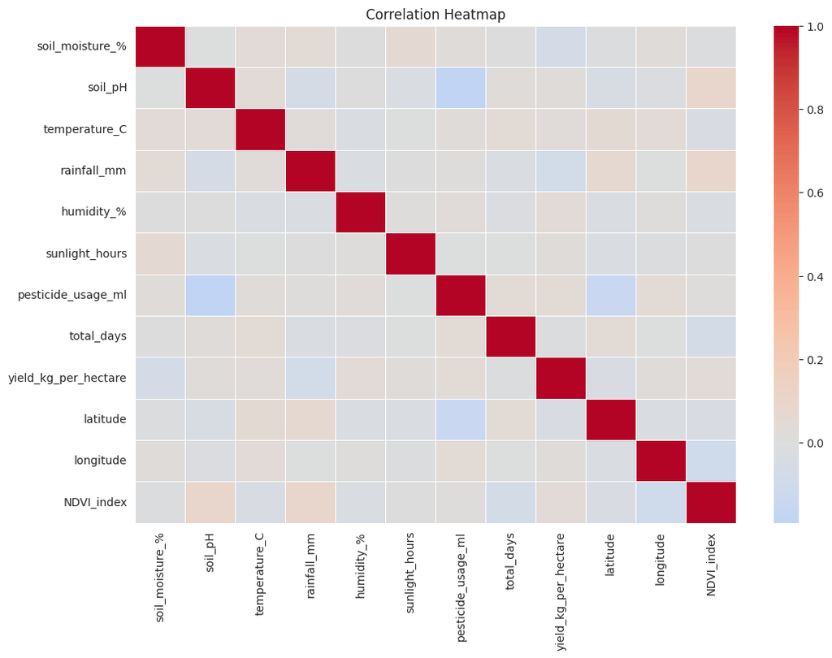

```python
# Visualize the correlation matrix as a heatmap
plt.figure(figsize=(12, 8))
sns.heatmap(
    corr_matrix,
    cmap="coolwarm",
    center=0,
    linewidths=0.5
)
plt.title("Correlation Heatmap")
plt.show()
```

### **Correlation with Target Only**

Below code extracts and sorts the **correlation values** between the `yield_kg_per_hectare` column and all other numeric variables in the dataset. It starts by selecting the `yield_kg_per_hectare` row (or column) from the previously computed `corr_matrix`, then sorts these correlation coefficients in **descending order** using `.sort_values(ascending=False)`. The result, `corr_target`, is a pandas Series that ranks variables by the strength of their linear relationship with yield, making it easy to identify which factors are most positively or negatively associated with crop productivity. This helps prioritize features for further analysis or modeling.

```python
# Extract and sort correlations with the target variable (yield)
corr_target = corr_matrix["yield_kg_per_hectare"].sort_values(ascending=False)
corr_target
```

|  | yield_kg_per_hectare |
| --- | --- |
| yield_kg_per_hectare | 1.00 |
| pesticide_usage_ml | 0.04 |
| humidity_% | 0.04 |
| NDVI_index | 0.04 |
| temperature_C | 0.03 |
| soil_pH | 0.02 |
| longitude | 0.02 |
| sunlight_hours | 0.02 |
| total_days | -0.01 |
| latitude | -0.04 |
| soil_moisture_% | -0.06 |
| rainfall_mm | -0.08 |

**dtype:** float64

The sorted correlation values reveal that **none of the numeric variables** in the dataset exhibit a strong linear relationship with **crop yield (kg/hectare)**. The highest correlations are very weak: **pesticide usage, humidity, and NDVI index** each show a negligible positive correlation of **0.04**, while **temperature, soil pH, longitude, and sunlight hours** have similarly minimal positive associations (around **0.02–0.03**). Conversely, **latitude, soil moisture, and rainfall** exhibit slightly negative correlations (**-0.04 to -0.08**), suggesting a minor inverse relationship with yield. Overall, these results indicate that **linear correlations alone may not fully explain yield variability** in this dataset, and other factors—such as categorical variables, interactions, or non-linear relationships—may need to be explored for deeper insights.

Below code generates a **bar plot** to visually represent the correlation coefficients between `yield_kg_per_hectare` and all other numeric variables in the dataset. It starts by removing the self-correlation value (`yield_kg_per_hectare` with itself) using `.drop("yield_kg_per_hectare")`, then plots the remaining coefficients as bars with `plot(kind="bar")`. The plot is labeled with a title, **"Correlation with Yield"**, and a y-axis label, **"Correlation Coefficient"**, before being displayed with `plt.show()`. This visualization makes it easy to compare the strength and direction of linear relationships between each variable and crop yield at a glance.

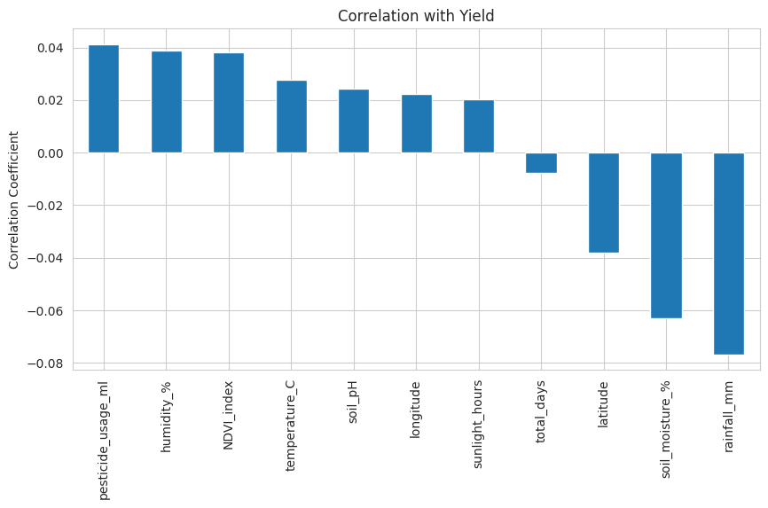

```python
# Plot the correlation coefficients with yield
corr_target.drop("yield_kg_per_hectare").plot(kind="bar")
plt.title("Correlation with Yield")
plt.ylabel("Correlation Coefficient")
plt.show()
```

The bar plot vividly illustrates the **correlation coefficients** between each numeric variable and **crop yield (kg/hectare)**, highlighting the strength and direction of their linear relationships. Most variables, such as **pesticide usage, humidity, NDVI index, temperature, soil pH, longitude, and sunlight hours**, exhibit **weak positive correlations** (around 0.02–0.04), suggesting minimal linear impact on yield. Conversely, **latitude, soil moisture, and rainfall** show **slightly stronger negative correlations** (up to -0.08), indicating a minor inverse relationship with yield. The overall near-zero values across all variables underscore that **linear correlations alone do not strongly explain yield variability** in this dataset, implying that other factors—such as categorical variables, non-linear relationships, or interactions—may play a more significant role in determining crop productivity.

## **11. Feature Relationships (Pairwise)**

Below code generates a **pairplot** to visualize the **pairwise relationships** between a subset of important numeric features in the dataset: `yield_kg_per_hectare`, `NDVI_index`, `rainfall_mm`, `soil_moisture_%`, `temperature_C`, and `humidity_%`. Using `sns.pairplot()` from the seaborn library, it creates a grid of scatter plots (for pairwise comparisons) and histograms (for univariate distributions) for each combination of these features. The plot is then displayed with `plt.show()`, allowing you to quickly identify patterns, correlations, clusters, or outliers among these key variables, which is especially useful for exploratory data analysis and understanding potential interactions.

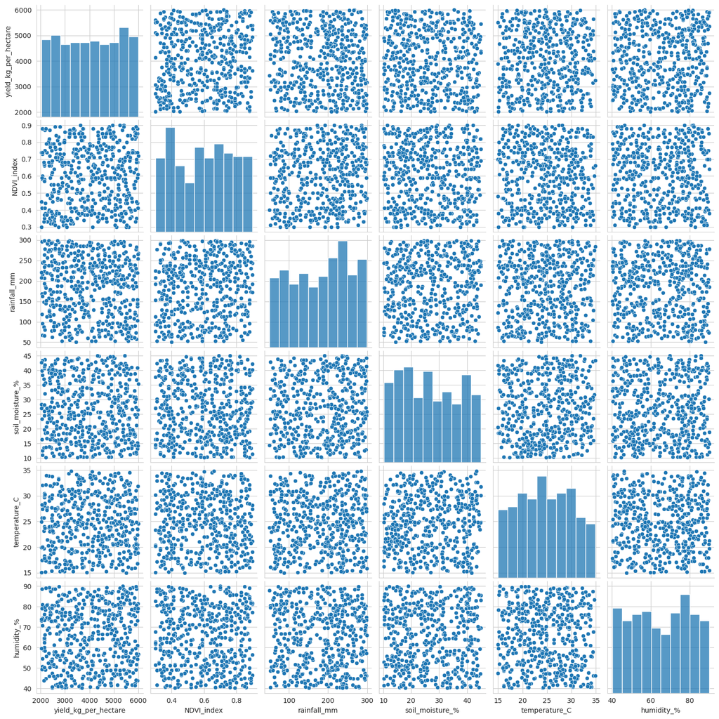

```python
# Plot pairwise relationships between important numerical features
important_features = [
    "yield_kg_per_hectare",
    "NDVI_index",
    "rainfall_mm",
    "soil_moisture_%",
    "temperature_C",
    "humidity_%"
]
sns.pairplot(df[important_features])
plt.show()
```

## **12. Temporal Feature Engineering**

Below code processes and extracts **temporal features** from the sowing and harvest date columns in the dataset. It first converts the `sowing_date` and `harvest_date` columns to **datetime objects** using `pd.to_datetime()`, enabling date-based operations. It then extracts the **month** from each date, storing the results in new columns: `sowing_month` and `harvest_month`. Additionally, it calculates the **duration of the growing season** in days by subtracting `sowing_date` from `harvest_date` and storing the result in `growing_duration_days`. Finally, it displays the first five rows of these newly created columns, providing a preview of the extracted temporal information. This transformation is useful for analyzing seasonal patterns and the impact of growing duration on crop yield.

```python
# Convert date columns to datetime objects
df["sowing_date"] = pd.to_datetime(df["sowing_date"])
df["harvest_date"] = pd.to_datetime(df["harvest_date"])

# Extract month and calculate growing duration
df["sowing_month"] = df["sowing_date"].dt.month
df["harvest_month"] = df["harvest_date"].dt.month
df["growing_duration_days"] = (df["harvest_date"] - df["sowing_date"]).dt.days

# Display the first 5 rows of the new temporal features
df[["sowing_month", "harvest_month", "growing_duration_days"]].head()
```

|  | sowing_month | harvest_month | growing_duration_days |
| --- | --- | --- | --- |
| 0 | 1 | 5 | 122 |
| 1 | 2 | 5 | 112 |
| 2 | 2 | 6 | 144 |
| 3 | 2 | 7 | 134 |
| 4 | 2 | 5 | 105 |

The output presents a **preview of the newly created temporal features** for the first five rows of the dataset. The `sowing_month` column indicates the month when crops were planted, with values like **January (1)** and **February (2)**, while the `harvest_month` column shows the month of harvest, such as **May (5)** and **June (6)**. The `growing_duration_days` column quantifies the total number of days between sowing and harvest, with values ranging from **105 to 144 days** in this sample. This transformation highlights the **seasonal timing** of agricultural activities and the variability in crop growth durations, which can be crucial for analyzing the impact of planting and harvesting times on yield and planning agricultural cycles.

Below code generates a **boxplot** to analyze the relationship between the **sowing month** and **crop yield (kg/hectare)**. It uses `sns.boxplot()` from the seaborn library, with `x=df["sowing_month"]` representing the sowing months on the x-axis and `y=df["yield_kg_per_hectare"]` showing the yield values on the y-axis. The plot is titled **"Yield vs Sowing Month"** and displayed with `plt.show()`. This visualization helps identify variations in yield across different sowing months, revealing potential seasonal effects on crop productivity, such as differences in median yield, variability, and outliers.

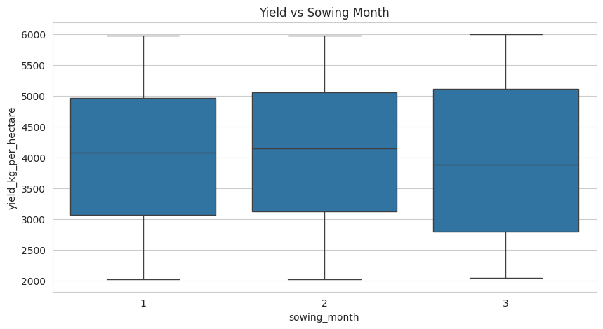

```python
# Create a boxplot to analyze the relationship between sowing month and crop yield
# - x-axis: sowing_month (categorical variable representing the month when crops were sown)
# - y-axis: yield_kg_per_hectare (numerical variable representing crop yield)
sns.boxplot(x=df["sowing_month"], y=df["yield_kg_per_hectare"])

# Add a title to the plot for clarity
plt.title("Yield vs Sowing Month")

# Display the plot
plt.show()
```

The boxplot illustrates the **relationship between sowing month and crop yield (kg/hectare)**, focusing on the first three months of the year. The median yield is **consistently around 4000 kg/hectare** for sowing months **January (1)**, **February (2)**, and **March (3)**, indicating similar central productivity across these months. The interquartile ranges (the boxes) are also comparable, suggesting that yield variability is relatively stable regardless of the sowing month. The whiskers, which represent the spread of the data, show that yields typically range from **about 2000 to 6000 kg/hectare** for all three months, with no significant outliers. This suggests that **sowing month may not have a strong impact on yield variability** within this timeframe, and other factors might play a more critical role in determining crop productivity.